# IE425 HW2. Batuhan Sarıtaş 2018402153

We are given the data containing quarterly gasoline and dieselş sales between 200* and 2006, and a number o potential independent variables. Our task is to construct a time series model and use regression to predict quarterly sales for year 2007. Firstly, let us examine the data.

```r
data_path='IE360_Spring22_HW2_data.csv'
sales = read.csv(data_path,colClasses=c('character',rep('numeric',10)))

sales$Quarter=as.Date(as.yearqtr(sales$Quarter, format = "%Y_Q%q"))
sales_test <- sales[c(29,30,31,32),]
sales <- sales[c(1:28),]
```

```r
summary(sales)
```

```
##     Quarter           Unleaded.Gasoline.Sale..UGS.      RNUV
##  Min.   :2000-01-01   Min.   : 736580              Min.   :0.001200
##  1st Qu.:2001-09-08   1st Qu.: 876211              1st Qu.:0.003950
##  Median :2003-05-16   Median : 983573              Median :0.005900
##  Mean   :2003-05-17   Mean   : 987212              Mean   :0.008732
##  3rd Qu.:2005-01-23   3rd Qu.:1097324              3rd Qu.:0.013625
##  Max.   :2006-10-01   Max.   :1370167              Max.   :0.020700
##  X..LPG.Vehicles..NLPG. Price.of.Unleaded.Gasoline..PU.
##  Min.   : 940000        Min.   :402.1
##  1st Qu.: 984375        1st Qu.:475.9
##  Median :1095500        Median :513.6
##  Mean   :1236027        Mean   :512.7
##  3rd Qu.:1503000        3rd Qu.:565.2
##  Max.   :1696000        Max.   :609.0
##  Price.of.Diesel.Gasoline..PG. X..Unleaded.Gasoline.Vehicles..NUGV.
##  Min.   :300.7                 Min.   :4647500
##  1st Qu.:354.9                 1st Qu.:5018631
##  Median :386.6                 Median :5135597
##  Mean   :393.5                 Mean   :5201394
##  3rd Qu.:441.4                 3rd Qu.:5367170
##  Max.   :471.9                 Max.   :5825866
##  X..of.Diesel.Gasoline.Vehicles..NDGV. GNP.Agriculture    GNP.Commerce
##  Min.   :282.0                         Min.   : 832953   Min.   :3374849
##  1st Qu.:286.3                         1st Qu.:1334578   1st Qu.:4387321
##  Median :288.1                         Median :1850657   Median :5046473
##  Mean   :298.6                         Mean   :2871250   Mean   :5117901
##  3rd Qu.:306.7                         3rd Qu.:3922950   3rd Qu.:5917790
##  Max.   :339.2                         Max.   :6974808   Max.   :7124204
##    GNP.Total
##  Min.   :15832648
##  1st Qu.:21499930
##  Median :24756112
##  Mean   :25133925
##  3rd Qu.:28942418
##  Max.   :34992138
```

```r
sales=data.table(sales)
print(sales)
```

```
##        Quarter Unleaded.Gasoline.Sale..UGS.   RNUV X..LPG.Vehicles..NLPG.
##  1: 2000-01-01                      1128971 0.0146                 940000
##  2: 2000-04-01                      1199569 0.0205                 941000
##  3: 2000-07-01                      1370167 0.0207                 943500
##  4: 2000-10-01                      1127548 0.0163                 948000
##  5: 2001-01-01                      1033918 0.0071                 950000
##  6: 2001-04-01                      1019754 0.0051                 955000
##  7: 2001-07-01                      1209916 0.0041                 967500
##  8: 2001-10-01                      1002789 0.0048                 990000
##  9: 2002-01-01                       893722 0.0012                1000000
## 10: 2002-04-01                      1027252 0.0032                1001000
## 11: 2002-07-01                      1153265 0.0034                1003500
## 12: 2002-10-01                       991981 0.0044                1008000
## 13: 2003-01-01                       806257 0.0019                1010000
## 14: 2003-04-01                       960556 0.0056                1048000
```

[output cut: 105 more lines]

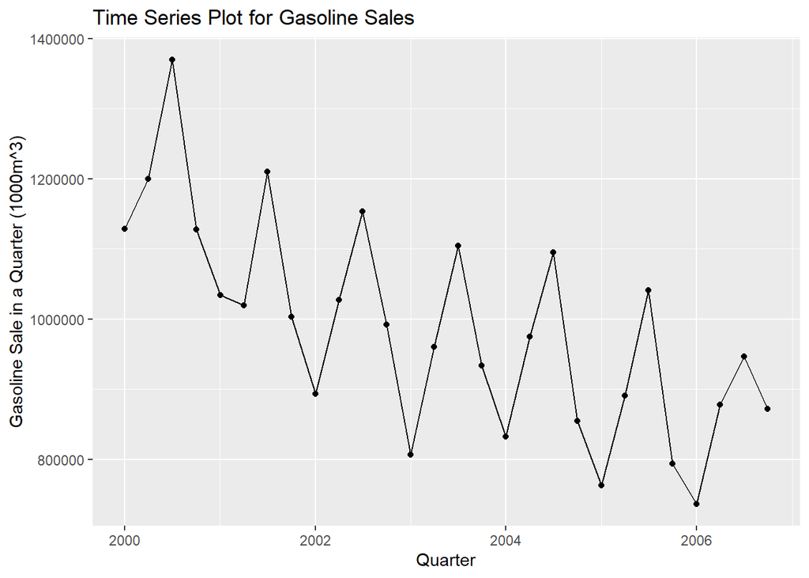

```r
ggplot(sales, aes(x=Quarter,y=Unleaded.Gasoline.Sale..UGS., group = 1),
) + geom_point() + geom_line() +labs(y ='Gasoline Sale in a Quarter (1000m^3)') + ggtitle('Time Series Plot for Gasoline Sales')
```

Time series of unleaded gasoline sales have highly time dependent mean and the mean is decreasing as the quarters pass. I think time series data is definitely not stationary in terms of its mean. On the other hand, its variance doesn’t show significant fluctuations over time. Although variance between 2000 and 2002 is greater than the variance observed in the following years, visibly, time series might be claimed to have stationary variance. Let us check the stationary of this time series by using time windows for each year.

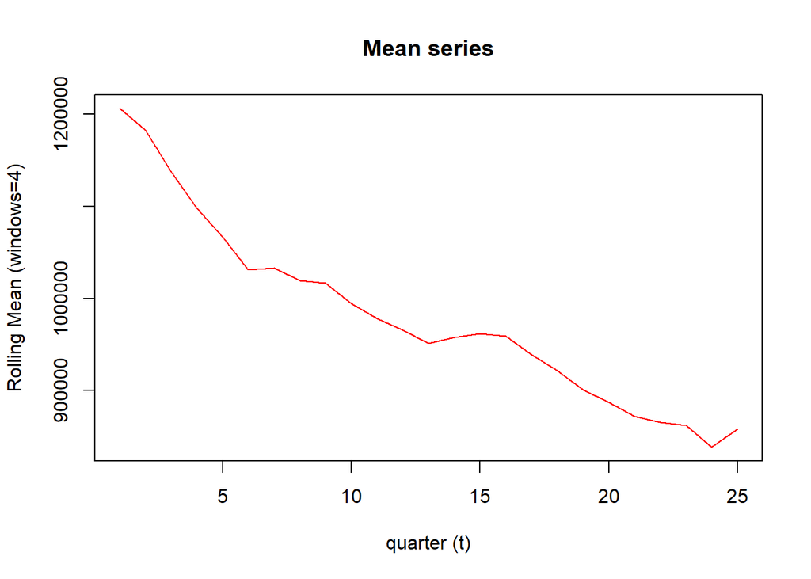

```r
time_window=4
mean_series=roll_mean(sales$Unleaded.Gasoline.Sale..UGS.,time_window,align='left')
var_series=roll_var(sales$Unleaded.Gasoline.Sale..UGS.,time_window,align='left')

plot(mean_series,
     type='l',col='red',
     xlab = "quarter (t)",
     ylab = "Rolling Mean (windows=4)",
     main = "Mean series")
```

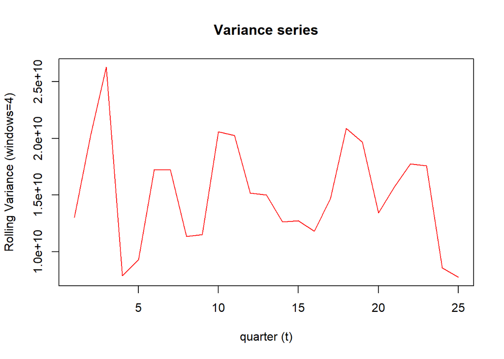

```r
plot(var_series,
     type='l',col='red',
     xlab = "quarter (t)",
     ylab = "Rolling Variance (windows=4)",
     main = "Variance series")
```

Rolling mean graph clearly shows the unstationarity in the time series. Rolling variance seems much more stable compared to mean. It is justified to claim that time series is not stationary as a conclusion.

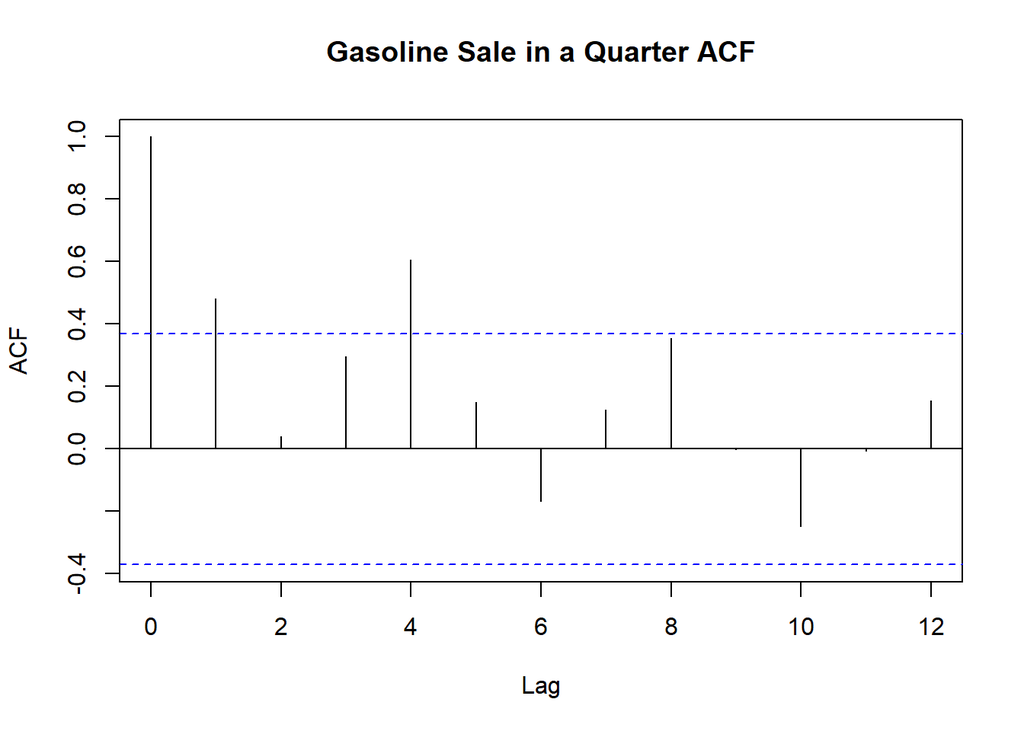

```r
AutoCorrelation <- acf(sales$Unleaded.Gasoline.Sale..UGS., lag.max = 12, plot = FALSE)
plot(AutoCorrelation, main = "Gasoline Sale in a Quarter ACF")
```

Autocorrelation function of the time series shows us the existence of seasonality if any exists. It is observed that correlation is relatively high at each lag value multiple of 4. Autocorrelation patterns show yearly repetitions and it might be claimed that there is a seasonaliy between the nth quarter of year t and nth quarter of year t-1. Let us detrend the data creating windows for each 4 quarter and check the plot.

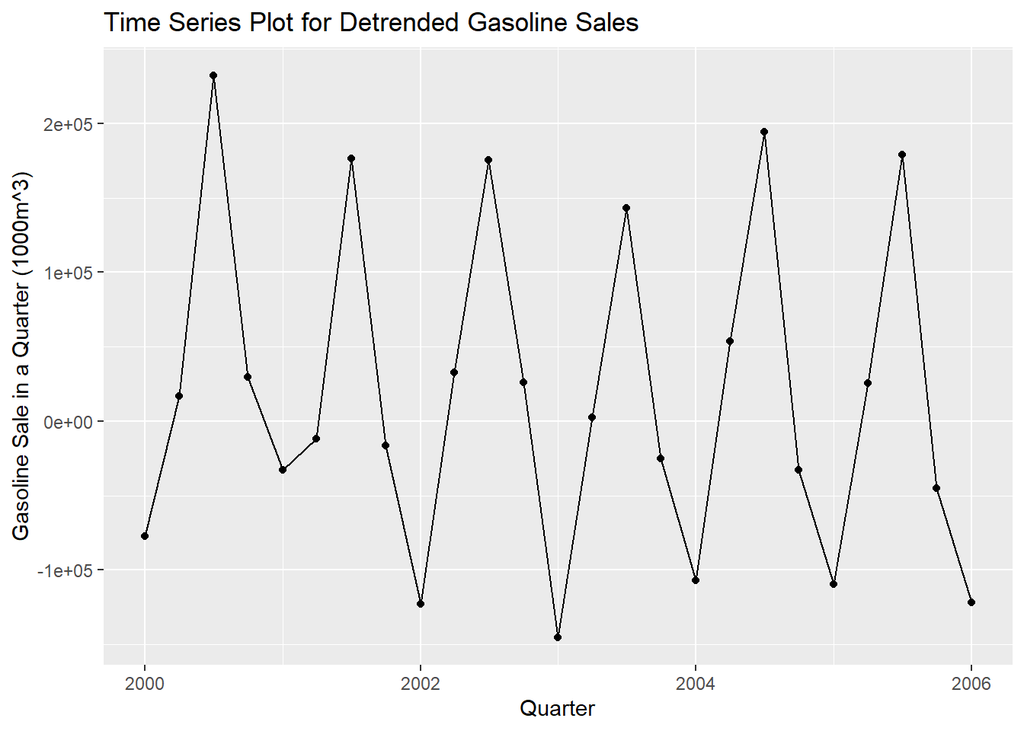

```r
ggplot(sales[1:(nrow(sales)-3),], aes(x=Quarter,y=Unleaded.Gasoline.Sale..UGS.-mean_series, group = 1),
) + geom_point() + geom_line() +labs(y ='Gasoline Sale in a Quarter (1000m^3)') + ggtitle('Time Series Plot for Detrended Gasoline Sales')
```

Detrended time series shows the seasonality clearly. Each peak occurs at the interval of 4 data points.

```r
sales[,trend:=1:.N]
quarter=seq(1,4,by=1)
sales=cbind(sales,quarter)

summary(sales)
```

```
##     Quarter           Unleaded.Gasoline.Sale..UGS.      RNUV
##  Min.   :2000-01-01   Min.   : 736580              Min.   :0.001200
##  1st Qu.:2001-09-08   1st Qu.: 876211              1st Qu.:0.003950
##  Median :2003-05-16   Median : 983573              Median :0.005900
##  Mean   :2003-05-17   Mean   : 987212              Mean   :0.008732
##  3rd Qu.:2005-01-23   3rd Qu.:1097324              3rd Qu.:0.013625
##  Max.   :2006-10-01   Max.   :1370167              Max.   :0.020700
##  X..LPG.Vehicles..NLPG. Price.of.Unleaded.Gasoline..PU.
##  Min.   : 940000        Min.   :402.1
##  1st Qu.: 984375        1st Qu.:475.9
##  Median :1095500        Median :513.6
##  Mean   :1236027        Mean   :512.7
##  3rd Qu.:1503000        3rd Qu.:565.2
##  Max.   :1696000        Max.   :609.0
##  Price.of.Diesel.Gasoline..PG. X..Unleaded.Gasoline.Vehicles..NUGV.
##  Min.   :300.7                 Min.   :4647500
##  1st Qu.:354.9                 1st Qu.:5018631
##  Median :386.6                 Median :5135597
##  Mean   :393.5                 Mean   :5201394
##  3rd Qu.:441.4                 3rd Qu.:5367170
##  Max.   :471.9                 Max.   :5825866
##  X..of.Diesel.Gasoline.Vehicles..NDGV. GNP.Agriculture    GNP.Commerce
##  Min.   :282.0                         Min.   : 832953   Min.   :3374849
##  1st Qu.:286.3                         1st Qu.:1334578   1st Qu.:4387321
##  Median :288.1                         Median :1850657   Median :5046473
##  Mean   :298.6                         Mean   :2871250   Mean   :5117901
##  3rd Qu.:306.7                         3rd Qu.:3922950   3rd Qu.:5917790
##  Max.   :339.2                         Max.   :6974808   Max.   :7124204
##    GNP.Total            trend          quarter
##  Min.   :15832648   Min.   : 1.00   Min.   :1.00
##  1st Qu.:21499930   1st Qu.: 7.75   1st Qu.:1.75
##  Median :24756112   Median :14.50   Median :2.50
##  Mean   :25133925   Mean   :14.50   Mean   :2.50
##  3rd Qu.:28942418   3rd Qu.:21.25   3rd Qu.:3.25
##  Max.   :34992138   Max.   :28.00   Max.   :4.00
```

```r
fit <- lm(Unleaded.Gasoline.Sale..UGS.~trend+as.factor(quarter) -Quarter, data = sales)
summary(fit)
```

```
##
## Call:
## lm(formula = Unleaded.Gasoline.Sale..UGS. ~ trend + as.factor(quarter) -
##     Quarter, data = sales)
##
## Residuals:
##    Min     1Q Median     3Q    Max
## -81167 -31283  -3458  28640  94502
##
## Coefficients:
##                     Estimate Std. Error t value Pr(>|t|)
## (Intercept)          1060372      23653  44.830  < 2e-16 ***
## trend                 -13497       1147 -11.764 3.28e-11 ***
## as.factor(quarter)2   121532      25987   4.677 0.000104 ***
## as.factor(quarter)3   273619      26063  10.498 3.03e-10 ***
## as.factor(quarter)4    95049      26189   3.629 0.001405 **
## ---
## Signif. codes:  0 '***' 0.001 '**' 0.01 '*' 0.05 '.' 0.1 ' ' 1
##
## Residual standard error: 48570 on 23 degrees of freedom
## Multiple R-squared:  0.9119, Adjusted R-squared:  0.8966
## F-statistic: 59.53 on 4 and 23 DF,  p-value: 8.446e-12
```